# Aprendiendo a Trabajar en R

Segundo encuentro

Pablo Ortiz

Octubre de 2019

# Manipulación de Bases de Datos

En este encuentro trabajaremos con el paquete [Tidyverse](https://www.tidyverse.org/). El mismo agrupa una serie de paquetes que tienen una misma lógica en su diseño y por ende funcionan en armonía.

[figure not shown]

Entre ellos usaremos principalmente **dplyr** y **tidyr** para realizar transformaciones sobre nuestro set de datos, y **ggplot** para generar gráficos.

A continuación cargamos la librería a nuestro ambiente. Para ello debemos tenerla previamente instalada.

```r
#rm(list = ls())  # Antes limpiamos/liberamos el Environment

# La librería debe instalarse solo la primera vez
# install.packages("tidyverse")
library(tidyverse)  # Las librerías deben "cargarse" cada vez que reiniciamos la sesión de trabajo
```

Para mostrar el funcionamiento básico de tydyverse usaremos un ejemplo de juguete:

```r
INDICE  <- c(100,   100,   100,
             101.8, 101.2, 100.73,
             102.9, 102.4, 103.2)
FECHA  <-  c("Jul-19", "Jul-19", "Jul-19",
             "Sep-19", "Sep-19", "Sep-19",
             "Oct-19", "Oct-19", "Oct-19")
GRUPO  <-  c("Privado_Registrado","Público","Privado_No_Registrado",
             "Privado_Registrado","Público","Privado_No_Registrado",
             "Privado_Registrado","Público","Privado_No_Registrado")

Datos <- data.frame(INDICE, FECHA, GRUPO)  # Todos elementos que incorporan para "construir" el data frame deben tener la misma longitud

Datos
```

| INDICE | FECHA | GRUPO |
| --- | --- | --- |
| 100.00 | Jul-19 | Privado_Registrado |
| 100.00 | Jul-19 | Público |
| 100.00 | Jul-19 | Privado_No_Registrado |
| 101.80 | Sep-19 | Privado_Registrado |
| 101.20 | Sep-19 | Público |
| 100.73 | Sep-19 | Privado_No_Registrado |
| 102.90 | Oct-19 | Privado_Registrado |
| 102.40 | Oct-19 | Público |
| 103.20 | Oct-19 | Privado_No_Registrado |

## dplyr

El caracter principal para utilizar este paquete es `%>%` , *pipe* (de tubería).

- *shortcut key*: [ CTRL + SHIFT + M]

Los `%>%` toman el set de datos a su izquierda, y los transforman mediante los comandos o funciones a su derecha, donde los elementos de la izquierda quedan implícitos. Es decír, que una vez específicado el `dataframe` con el cual se trabaja, no será necesario nombrarlo nuevamente para referirse a una determinada variable (columna) del mismo.

A continuación veremos las principales funciones que pueden utilizarse con la lógica de este paquete.

### filter

Permite filtrar la tabla acorde al cumplimiento de condiciones lógicas.

```r
Datos %>%
  filter(INDICE > 101 , GRUPO == "Privado_Registrado")
```

| INDICE | FECHA | GRUPO |
| --- | --- | --- |
| 101.8 | Sep-19 | Privado_Registrado |
| 102.9 | Oct-19 | Privado_Registrado |

Comentarios:

- Al separar con una `,` se exige el cumplimiento de ambas condiciones (conjunción).
- En caso de desear que se cumpla una sola condición debe utilizarse el caracter `|` (representa disyunción).

```r
Datos %>%
  filter(INDICE > 101 | GRUPO == "Privado_Registrado")
```

| INDICE | FECHA | GRUPO |
| --- | --- | --- |
| 100.0 | Jul-19 | Privado_Registrado |
| 101.8 | Sep-19 | Privado_Registrado |
| 101.2 | Sep-19 | Público |
| 102.9 | Oct-19 | Privado_Registrado |
| 102.4 | Oct-19 | Público |
| 103.2 | Oct-19 | Privado_No_Registrado |

### rename

Permite renombrar una columna del `data frame`. Funciona de la siguiente manera: `Data %>% rename( nuevo_nombre = viejo_nombre )`

```r
Datos %>%
  rename(Periodo = FECHA)
```

| INDICE | Periodo | GRUPO |
| --- | --- | --- |
| 100.00 | Jul-19 | Privado_Registrado |
| 100.00 | Jul-19 | Público |
| 100.00 | Jul-19 | Privado_No_Registrado |
| 101.80 | Sep-19 | Privado_Registrado |
| 101.20 | Sep-19 | Público |
| 100.73 | Sep-19 | Privado_No_Registrado |
| 102.90 | Oct-19 | Privado_Registrado |
| 102.40 | Oct-19 | Público |
| 103.20 | Oct-19 | Privado_No_Registrado |

**Observación:** a diferencia del ejemplo de la función **filter** donde utilizábamos **==** para comprobar una condición lógica, en este caso se utiliza sólo un **=** ya que lo estamos haciendo es *asignar* un nombre.

### mutate

Permite agregar una variable al `data frame` (especificando el nombre que tomará). Una característica importante es que puede ser el resultado de operaciones sobre otras variables del mismo dataset.

En caso de especificar el nombre de una columna existente, el resultado de la operación realizada “sobrescribirá” la información de la columna con dicho nombre

```r
Datos <- Datos %>%
  mutate(Doble = INDICE*2)
Datos
```

| INDICE | FECHA | GRUPO | Doble |
| --- | --- | --- | --- |
| 100.00 | Jul-19 | Privado_Registrado | 200.00 |
| 100.00 | Jul-19 | Público | 200.00 |
| 100.00 | Jul-19 | Privado_No_Registrado | 200.00 |
| 101.80 | Sep-19 | Privado_Registrado | 203.60 |
| 101.20 | Sep-19 | Público | 202.40 |
| 100.73 | Sep-19 | Privado_No_Registrado | 201.46 |
| 102.90 | Oct-19 | Privado_Registrado | 205.80 |
| 102.40 | Oct-19 | Público | 204.80 |
| 103.20 | Oct-19 | Privado_No_Registrado | 206.40 |

### case_when

Permite definir una variable que tome un valor particular para cada condición establecida. En caso de no cumplir ninguna de las condiciones establecidas la variable tomará valor **NA**.

Su funcionamiento es el siguiente:  
`case_when(condicion1 ~ "Valor1", condicion2 ~ "Valor2", condicion3 ~ "Valor3")`

```r
Datos <- Datos %>%
  mutate(Caso_cuando = case_when(GRUPO == "Privado_Registrado"   ~ INDICE*2,
                                 GRUPO == "Público"              ~ INDICE*3,
                                 GRUPO == "Privado_No_Registrado"~ INDICE*5))
Datos
```

| INDICE | FECHA | GRUPO | Doble | Caso_cuando |
| --- | --- | --- | --- | --- |
| 100.00 | Jul-19 | Privado_Registrado | 200.00 | 200.00 |
| 100.00 | Jul-19 | Público | 200.00 | 300.00 |
| 100.00 | Jul-19 | Privado_No_Registrado | 200.00 | 500.00 |
| 101.80 | Sep-19 | Privado_Registrado | 203.60 | 203.60 |
| 101.20 | Sep-19 | Público | 202.40 | 303.60 |
| 100.73 | Sep-19 | Privado_No_Registrado | 201.46 | 503.65 |
| 102.90 | Oct-19 | Privado_Registrado | 205.80 | 205.80 |
| 102.40 | Oct-19 | Público | 204.80 | 307.20 |
| 103.20 | Oct-19 | Privado_No_Registrado | 206.40 | 516.00 |

### select

Permite especificar la serie de columnas que se desea conservar de un dataset. También pueden especificarse las columnas que se desean descartar (agregándoles un *-* adelante). Resulta muy útil para agilizar el trabajo en bases de datos de gran tamaño.

```r
Datos2 <- Datos %>%
  select(INDICE, FECHA, GRUPO)
Datos2
```

| INDICE | FECHA | GRUPO |
| --- | --- | --- |
| 100.00 | Jul-19 | Privado_Registrado |
| 100.00 | Jul-19 | Público |
| 100.00 | Jul-19 | Privado_No_Registrado |
| 101.80 | Sep-19 | Privado_Registrado |
| 101.20 | Sep-19 | Público |
| 100.73 | Sep-19 | Privado_No_Registrado |
| 102.90 | Oct-19 | Privado_Registrado |
| 102.40 | Oct-19 | Público |
| 103.20 | Oct-19 | Privado_No_Registrado |

```r
Datos <- Datos %>%
  select(-c(Doble, Caso_cuando))
Datos
```

| INDICE | FECHA | GRUPO |
| --- | --- | --- |
| 100.00 | Jul-19 | Privado_Registrado |
| 100.00 | Jul-19 | Público |
| 100.00 | Jul-19 | Privado_No_Registrado |
| 101.80 | Sep-19 | Privado_Registrado |
| 101.20 | Sep-19 | Público |
| 100.73 | Sep-19 | Privado_No_Registrado |
| 102.90 | Oct-19 | Privado_Registrado |
| 102.40 | Oct-19 | Público |
| 103.20 | Oct-19 | Privado_No_Registrado |

### arrange

Permite ordenar la tabla por los valores de determinada/s variable/s. Es útil cuando luego deben hacerse otras operaciones que requieran del ordenamiento del dataset.

```r
Datos <- Datos %>%
  arrange(GRUPO, INDICE)  # con el signo "-" a la izquierda, ordena de mayor a menor
Datos
```

| INDICE | FECHA | GRUPO |
| --- | --- | --- |
| 100.00 | Jul-19 | Privado_No_Registrado |
| 100.73 | Sep-19 | Privado_No_Registrado |
| 103.20 | Oct-19 | Privado_No_Registrado |
| 100.00 | Jul-19 | Privado_Registrado |
| 101.80 | Sep-19 | Privado_Registrado |
| 102.90 | Oct-19 | Privado_Registrado |
| 100.00 | Jul-19 | Público |
| 101.20 | Sep-19 | Público |
| 102.40 | Oct-19 | Público |

### summarise

Crea una nueva tabla que resume la información original. Para ello, definimos las variables de resumen y las formas de agregación.

```r
Datos %>%
  summarise(Indprom = mean(INDICE))
```

| Indprom |
| --- |
| 101.3589 |

### group_by

Esta función permite realizar operaciones de forma agrupada. Lo que hace la función es “dividir” al dataset según los valores de la variable indicada y realizar las operaciones que se especifican a continuación, de manera independiente para cada una de las “partes” del dataset.

Por ejemplo, calculemos el promedio de los indices por *Fecha*

```r
Datos %>%
  group_by(FECHA) %>%
  summarise(Indprom = mean(INDICE))  # Puede emplearse round(mean(INDICE), 2)
```

| FECHA | Indprom |
| --- | --- |
| Jul-19 | 100.0000 |
| Oct-19 | 102.8333 |
| Sep-19 | 101.2433 |

El operador `%>%` puede usarse de manera encadenada para realizar numerosos procedimientos sobre un dataframe.

Veamos un ejemplo con multiples encadenamientos:

```r
Encadenado <- Datos %>%
  filter(GRUPO == "Privado_Registrado") %>%
  rename(Periodo = FECHA) %>%
  mutate(Doble = INDICE*2) %>%
  select(-INDICE)
Encadenado
```

| Periodo | GRUPO | Doble |
| --- | --- | --- |
| Jul-19 | Privado_Registrado | 200.0 |
| Sep-19 | Privado_Registrado | 203.6 |
| Oct-19 | Privado_Registrado | 205.8 |

## Joins

Esta implementación del paquete dplyr son funciones para unir datasets (`joins`). Permite, por ejemplo, añadir nuevas variables provenientes de un dataset diferente.

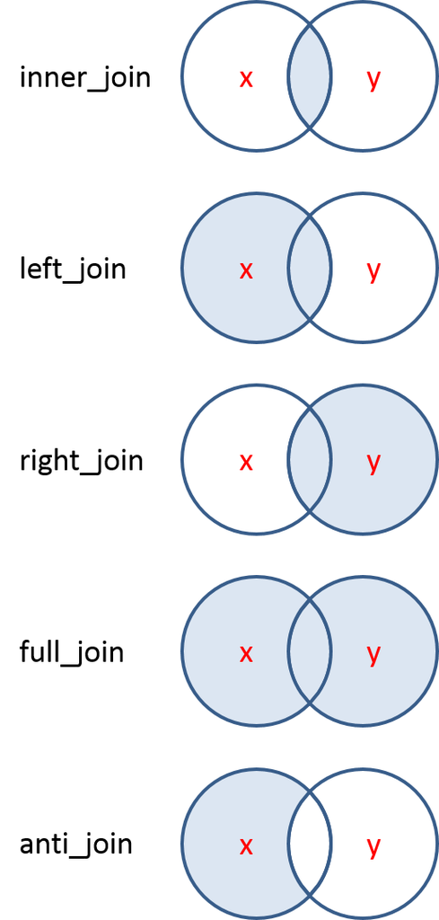

### left_join

Veamos un ejemplo de la función **left_join** (una de las más utilizadas en la práctica).  
- Crearemos previamente un `dataframe` que contenga un *Ponderador* para cada uno de los Grupos del dataset *Datos*. - Aprovecharemos el ejemplo para introducir la función **`weigthed.mean`**, que permite calcular un Indice Ponderado.

```r
Ponderadores <- data.frame(GRUPO = c("Privado_Registrado","Público","Privado_No_Registrado"),
                            PONDERADOR = c(50.16,29.91,19.93))
Ponderadores
```

| GRUPO | PONDERADOR |
| --- | --- |
| Privado_Registrado | 50.16 |
| Público | 29.91 |
| Privado_No_Registrado | 19.93 |

```r
Datos_join <- Datos %>%
  left_join(., Ponderadores, by = "GRUPO")
Datos_join
```

| INDICE | FECHA | GRUPO | PONDERADOR |
| --- | --- | --- | --- |
| 100.00 | Jul-19 | Privado_No_Registrado | 19.93 |
| 100.73 | Sep-19 | Privado_No_Registrado | 19.93 |
| 103.20 | Oct-19 | Privado_No_Registrado | 19.93 |
| 100.00 | Jul-19 | Privado_Registrado | 50.16 |
| 101.80 | Sep-19 | Privado_Registrado | 50.16 |
| 102.90 | Oct-19 | Privado_Registrado | 50.16 |
| 100.00 | Jul-19 | Público | 29.91 |
| 101.20 | Sep-19 | Público | 29.91 |
| 102.40 | Oct-19 | Público | 29.91 |

```r
Datos_Indice_Gral <- Datos_join %>%
  group_by(FECHA) %>%
  summarise(Indice_Gral = weighted.mean(INDICE, w = PONDERADOR))
Datos_Indice_Gral
```

| FECHA | Indice_Gral |
| --- | --- |
| Jul-19 | 100.0000 |
| Oct-19 | 102.8102 |
| Sep-19 | 101.4073 |

## Tidyr

El paquete tidyr esta pensado para facilitar la “reestructuración” de los datos.

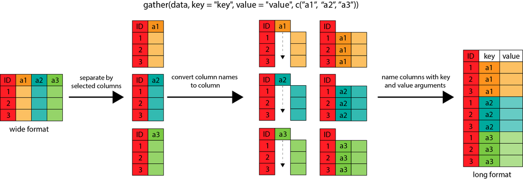

**gather** es una función que nos permite pasar los datos de forma horizontal a una forma vertical.

**spread** es una función que nos permite pasar los datos de forma vertical a una forma horizontal.

Retomemos el Dataframe original para mostrar como operan estas funciones:

```r
Datos
```

[output not shown]

### Gather y Spread

```r
Datos_Spread <- Datos %>%
  spread(.,       # el . llama a lo que esta atras del %>%
  key = GRUPO,    # la "llave" es la variable cuyos valores van a dar los nombres de columnas
  value = INDICE) # los valores con que se llenan las celdas
Datos_Spread
```

| FECHA | Privado_No_Registrado | Privado_Registrado | Público |
| --- | --- | --- | --- |
| Jul-19 | 100.00 | 100.0 | 100.0 |
| Oct-19 | 103.20 | 102.9 | 102.4 |
| Sep-19 | 100.73 | 101.8 | 101.2 |

```r
##La función opuesta (gather) nos permite obtener un dataframe como el original partiendo de un dataframe como el recién construido.

Datos_gather <- Datos_Spread %>%
  gather(.,         # el . llama a lo que esta atras del %>%
   key   = GRUPO,   # como se llamará la variable que toma los nombres de las columnas
   value = INDICE,  # como se llamará la variable que toma los valores de las columnas
   2:4)             # le indico que columnas juntar
Datos_gather
```

| FECHA | GRUPO | INDICE |
| --- | --- | --- |
| Jul-19 | Privado_No_Registrado | 100.00 |
| Oct-19 | Privado_No_Registrado | 103.20 |
| Sep-19 | Privado_No_Registrado | 100.73 |
| Jul-19 | Privado_Registrado | 100.00 |
| Oct-19 | Privado_Registrado | 102.90 |
| Sep-19 | Privado_Registrado | 101.80 |
| Jul-19 | Público | 100.00 |
| Oct-19 | Público | 102.40 |
| Sep-19 | Público | 101.20 |

# Trabajo con múltiples bases de datos

Una de las ventajas de R es la posibilidad de trabajar con múltiples bases de datos (de distinta índole).

Trabajaremos con las bases de comercio exterior de la provincia de Córdoba

```r
# install.packages("foreign") # Permite levantar bases DBF
library(foreign)
```

```r
data_2016 <- read.dbf("data/122016.DBF")
data_2017 <- read.dbf("data/122017.DBF")

# Referencias países
codPaises <- read_csv("data/cod_paises.csv",
                      locale = locale(encoding = "ISO-8859-1"))  # Se agrega configuración
```

Agregamos los años a las bases de datos:

```r
# Alternativa 1 (con R base)
# data_2016$ano <- 2016

# Alternativa 2 (con dplyr)
data_2016 <- data_2016 %>%
  mutate('ano' = 2016)

data_2017 <- data_2017 %>%
  mutate('ano' = 2017)
```

Generamos una única base de datos:

```r
data <- rbind(data_2016, data_2017)
```

### Tareas

- Incorporar nombre de país, continente, zona y código iso a la base general (requiere adaptar ambas bases)
- Generar variables de exportación en millones de dólares y en toneladas (se encuentran en dólares y en kilogramos, respectivamente)
- Generar agregaciones de exportaciones por continente
- Calcular tasa de variación